# Basic programming

- Variable assignment
- Type : int, float, string
- Built-in function
- Data structure: list
- Control structures: while for if
- import packages
- Data structure: dictionary

# Pandas

- Load data from csv
- Data manipulation
- selecting iloc
- querying

คำสั่งอื่นๆ ของ DataFrame สามารถหาดูได้ที่นี่ https://pandas.pydata.org/pandas-docs/version/0.23.4/api.html#dataframe

```python
import pandas as pd
import numpy as np
from sklearn import linear_model
```

```python
3 + 7
```

```
10
```

```python
data = pd.read_csv("dataset.csv")
```

มีคอลัมน์ดังต่อไปนี้

CIK = Central Index Key (Equivalent to Company ID)

FYEAR = Fiscal Year

SIC2 = 2 digit industry code (where the company belongs to)

ABCFO = Abnormal Operating Cash Flows (Accounting variable)

ABACC = Abnormal Accruals (Accounting variable)

SIZE = Firm Size (Control variable)

MB = Market to book ratio (Control variable)

```python
data.sample(10)
```

|  | CIK | fyear | sic2 | ffind | abcfo | abacc | size | mb |
| --- | --- | --- | --- | --- | --- | --- | --- | --- |
| 1816 | 16873 | 1997 | 13 | OIL | 0.144562 | -0.010523 | 8.393970 | 3.535466 |
| 44240 | 1024342 | 2005 | 20 | FOOD | -0.003681 | 0.112839 | 2.035991 | 1.798984 |
| 58206 | 1593936 | 1998 | 59 | RTAIL | 0.013502 | 0.080226 | 6.285136 | 1.113432 |
| 2532 | 23082 | 2013 | 73 | BUSSV | 0.196442 | 0.038057 | 9.088696 | 2.263197 |
| 20349 | 791908 | 2000 | 28 | DRUGS | -0.319634 | -0.074458 | 6.470107 | -9.397012 |
| 41352 | 1003607 | 2002 | 36 | CHIPS | -0.166666 | 0.055857 | 1.974192 | 0.463750 |
| 30250 | 883569 | 2013 | 38 | HSHLD | 0.223522 | 0.102734 | 8.789154 | 6.140001 |
| 11186 | 106618 | 2000 | 33 | STEEL | 0.082050 | -0.229600 | 2.480103 | 0.061599 |
| 40634 | 1001039 | 2011 | 48 | TELCM | -0.001649 | 0.052450 | 10.880854 | 1.421638 |
| 52822 | 1135644 | 2005 | 99 | OTHER | 0.127171 | 0.190110 | 11.140526 | 2.107394 |

```python
data.head(20)
data.sample(20)
data.tail(5)
```

|  | CIK | fyear | sic2 | ffind | abcfo | abacc | size | mb |
| --- | --- | --- | --- | --- | --- | --- | --- | --- |
| 58571 | 1667415 | 2008 | 36 | CHIPS | 0.057842 | 0.057653 | 4.033711 | 0.290712 |
| 58572 | 1667415 | 2009 | 36 | CHIPS | 0.129487 | -0.040105 | 4.896935 | 0.650751 |
| 58573 | 1667415 | 2010 | 36 | CHIPS | 0.186063 | -0.029291 | 5.408618 | 0.844098 |
| 58574 | 1667415 | 2011 | 36 | CHIPS | 0.203115 | 0.009563 | 4.567273 | 0.312210 |
| 58575 | 1667415 | 2013 | 36 | CHIPS | 0.126624 | 0.005386 | 4.493118 | 0.281457 |

```python
col_names = ['CIK', 'size']
data[col_names].iloc[40:50]
```

|  | CIK | size |
| --- | --- | --- |
| 40 | 1800 | 11.196947 |
| 41 | 1800 | 11.195143 |
| 42 | 1800 | 11.013584 |
| 43 | 1800 | 11.223644 |
| 44 | 1800 | 11.335574 |
| 45 | 1800 | 11.335574 |
| 46 | 1800 | 11.213400 |
| 47 | 1800 | 11.335574 |
| 48 | 1800 | 11.335574 |
| 49 | 1800 | 10.991032 |

```python
data['abcfo'].head()
```

```
0    0.063865
1    0.112094
2    0.124414
3    0.024486
4   -0.109485
Name: abcfo, dtype: float64
```

```python
data[data['size'] < 1.65].count()
```

[output not shown]

```python
col_names = ['CIK', 'size']
my_query = 'size < 1.6 & mb > 0.3'
small_set = data.query(my_query)
small_set.count()
```

```
CIK      369
fyear    369
sic2     369
ffind    369
abcfo    369
abacc    369
size     369
mb       369
dtype: int64
```

# Pivot table

```python
dg = data.groupby('fyear')
```

```python
dg[['abcfo', 'abacc']].mean()
```

| fyear | abcfo | abacc |
| --- | --- | --- |
| 1995 | 0.026435 | 0.006342 |
| 1996 | 0.033677 | 0.006686 |
| 1997 | 0.040511 | 0.008079 |
| 1998 | 0.044208 | 0.015164 |
| 1999 | 0.057451 | 0.019284 |
| 2000 | 0.068746 | 0.025702 |
| 2001 | 0.067279 | 0.027228 |
| 2002 | 0.063620 | 0.018703 |
| 2003 | 0.054330 | 0.023884 |
| 2004 | 0.076261 | 0.019680 |
| 2005 | 0.069730 | 0.019513 |
| 2006 | 0.070511 | 0.022339 |
| 2007 | 0.072764 | 0.010865 |
| 2008 | 0.059087 | 0.015168 |
| 2009 | 0.055277 | 0.014694 |
| 2010 | 0.058438 | 0.017044 |
| 2011 | 0.068221 | 0.016729 |
| 2012 | 0.070542 | 0.015025 |
| 2013 | 0.087304 | 0.026153 |
| 2014 | 0.143638 | 0.011152 |

# ข้อมูลชุดนี้มีกี่ CIK

สามารถศึกษา function เพิ่มเติมจาก https://pandas.pydata.org/pandas-docs/version/0.23.4/generated/pandas.Series.html

ข้อมูลชุดนี้บริษัท 7616 ที่

```python
data['CIK'].nunique()
```

```
7616
```

```python
data['CIK'].unique()
```

```
array([     20,    1750,    1761, ..., 1661290, 1667280, 1667415])
```

# ข้อมูลชุดนี้จากปีไหน ถึงปีไหน

```python
data['fyear'].unique()
```

```
array([1995, 1996, 1997, 1998, 1999, 2000, 2001, 2002, 2003, 2004, 2005,
       2006, 2007, 2008, 2009, 2010, 2011, 2013, 2012, 2014])
```

```python
data['mb'].describe()
```

```
count    58576.000000
mean         2.916774
std          4.015625
min         -9.397012
25%          1.153399
50%          1.975979
75%          3.464971
max         25.858743
Name: mb, dtype: float64
```

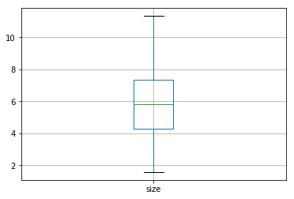

```python
data.boxplot('size')
```

```
array([[<matplotlib.axes._subplots.AxesSubplot object at 0x1a1985dfd0>]],
      dtype=object)
```

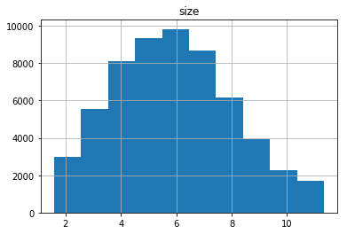

```python
data.hist('size')
```

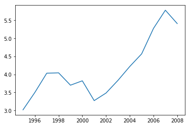

```python
%matplotlib inline
import matplotlib.pyplot as plt
oneyear = data[data['CIK'] == 20]
plt.plot(oneyear['fyear'], oneyear['size'])
```

# Linear regression

fit linear regression แต่ละ fiscal year และเปรียบเทียบ coefficient

```python
from sklearn import linear_model
```

มีคอลัมน์ดังต่อไปนี้

CIK = Central Index Key (Equivalent to Company ID)

FYEAR = Fiscal Year

SIC2 = 2 digit industry code (where the company belongs to)

ABCFO = Abnormal Operating Cash Flows (Accounting variable)

ABACC = Abnormal Accruals (Accounting variable)

SIZE = Firm Size (Control variable)

MB = Market to book ratio (Control variable)

```python
data = pandas.read_csv('dataset.csv')
model = linear_model.Lasso()
x = ['abcfo', 'abacc']
y = 'mb'
model.fit(data[x], data[y])
```

```
Lasso(alpha=1.0, copy_X=True, fit_intercept=True, max_iter=1000,
   normalize=False, positive=False, precompute=False, random_state=None,
   selection='cyclic', tol=0.0001, warm_start=False)
```

```python
model.coef_
```

```
array([0.65358428, 0.29192442])
```

```python
model.intercept_
```

```
2.8724404385160427
```

```python
fyear_list = data['fyear'].unique()
sic2_list = data['sic2'].unique()
for sic2 in sic2_list:
    for fyear in fyear_list:
        one_fyear = data[data['fyear'] == fyear]
        one_fyear = one_fyear[one_fyear['sic2'] == sic2]
        model = linear_model.LinearRegression()
        x = ['abcfo', 'size','mb']
        y = 'abacc'
        num_row = one_fyear.shape[0]
        if num_row > 0:
            model.fit(one_fyear[x], one_fyear[y])
            print (sic2, fyear, model.intercept_, model.coef_, one_fyear.shape[0])
```

```
38 1995 -0.0024897956238492634 [-0.21013807  0.0113955  -0.00819699] 248
38 1996 0.0005546227453986849 [-0.10835668  0.00417682 -0.00208929] 255
38 1997 -0.054929156658769934 [-0.07295379  0.01524938 -0.00297653] 246
38 1998 0.04402437465176489 [ 0.01772236  0.00147877 -0.00636887] 257
38 1999 -0.02890047058218015 [-0.03774348  0.01238947 -0.00183656] 259
38 2000 0.013562927900050323 [-0.06026588  0.0017985   0.0016957 ] 253
38 2001 -0.02548642409674306 [0.00659577 0.00758846 0.00228073] 237
38 2002 -0.035746529426274036 [-0.20370657  0.01497231  0.00059235] 265
38 2003 0.0020105445859945094 [ 0.01522421  0.00385075 -0.00072978] 250
38 2004 0.04799428841244208 [-0.17536589  0.00267153 -0.0043115 ] 244
38 2005 0.02597058736251375 [-0.14889407  0.00217433  0.00052664] 220
38 2006 0.009944088251534054 [-0.09081714  0.00197897  0.00646994] 216
38 2007 0.006126347617064282 [-0.05205745  0.00541409 -0.00632634] 215
38 2008 -0.017059866802036666 [-0.12394721  0.01059697  0.00287448] 213
38 2009 0.03572735734898688 [-0.1059494   0.00016607 -0.00192666] 205
```

[output cut: 924 more lines]

# Random sampling

```python
np.random.uniform(0, 1, 10)
```

```
array([0.41674627, 0.92151729, 0.44282505, 0.22450577, 0.7072295 ,
       0.56832031, 0.79278281, 0.95915418, 0.82349459, 0.05430384])
```